# TestBash Manchester

Raúl Nicolás and Elysia Altuntas

27/10/2016

# Hello world!

Welcome to our [Testbash](http://http://www.ministryoftesting.com/training-events/testbash-manchester/) experience

[figure not shown]

[figure not shown]

# [James Bach](https://twitter.com/jamesmarcusbach). Don’t think so close to me: Managing Critical and Social distance by testing

- Critical distance both helps and harms testing and development
1. Helps preventing shared errors
2. Helps increasing innovation
3. Helps detecting errors that do occur
4. Different people and processes would lead to different results/conclusions

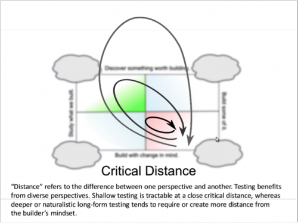

Critical Distance

# [James Bach](https://twitter.com/jamesmarcusbach). Don’t think so close to me

- Social distance concept: free flow of information
1. Can be very harmful. Social forces corode critical distance
2. Cause or hide errors by reducing the sharing of critical information
3. Open plan offices work differently for different teams. Need of breakout areas
4. I got my job - you have yours

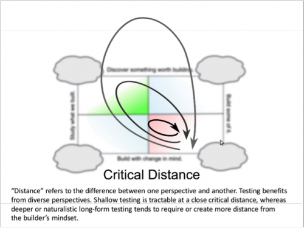

Critical Distance

# [James Bach](https://twitter.com/jamesmarcusbach). Don’t think so close to me

| Social Distance | Critical Distance |  |
| --- | --- | --- |
| low | low | Harmonious |
| low | high | Productive |
| high | high | Irritating |
| high | low | Reticent |

Heuristic for technical teams: Cultivate CD an Eliminate SD

# [James Bach](https://twitter.com/jamesmarcusbach). Don’t think so close to me

In some ways reducing CD can make testing better! - Code reviews to give ideas for testing

Multiple mindsets are critical (Test/Dev/BA) - Perm and short term

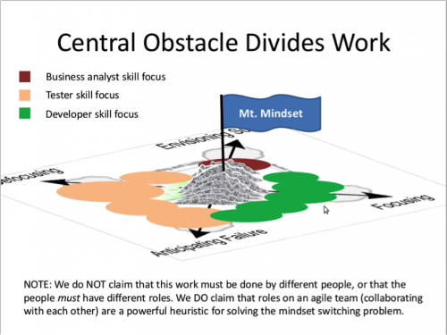

Mount Mindset

# Ian Bright. Psychology of asking questions

- Challenge yourself internally first
1. Keep asking
2. Rephrase
3. Why do you think it is important?
4. What are you trying to achieve?
- Questions are a tool to influence and change behaviour
- Foot in the door, door in the face
- Get the team asking questions
1. What is the risk
2. What is the impact
3. What is the value

# Ian Bright. Psychology of asking questions

- Get other to ask questions on our behalf
1. Propose a new apporach
2. Challenging proposals
3. Objective
- Utilise the good relationship between users and developers

# [Kim Knup](https://twitter.com/Punkmik). On positivity - Turning that frown upside down

- Positive testing: Works as expected
- Negative testing: handling invalid requests
- Quality cannot be added to the product by testing you inform about the existing one

# [Kim Knup](https://twitter.com/Punkmik). On positivity - Turning that frown upside down

- Embracing Positivity: Advantages
1. Wider perspective
2. Increased activity
3. stamina
- Become happier
1. Be grateful
2. Meditation
3. Random acts of kindness
- People and interactions over tools and processes

# [Stepehen Mounsey](https://twitter.com/stephenmounsey). Listening: An essential skill for software testers

-Is easier to prove the presence of a problem than the absence of it

-How do we listen?

1. Reductively (listening ‘for’, men typically listen like this)
2. Expansively (listening ‘with’, women typically listen expansively)

-Note the amount of info we naturally block out every day

-Listening is not about us, it is about the speaker

# [Stepehen Mounsey](https://twitter.com/stephenmounsey). Listening: An essential skill for software testers

L ook and listen  
I nterrupt  
S ummarise  
T est  
E valuate  
N eutralize

[figure not shown]

Sketch

# [Duncan Nisbet](https://twitter.com/DuncNisbet). Testers! Be more Salmon!

-Context is KING

-Shared documentation does not equal shared understanding

-Testing is asking questions to squash assumptions

-Ask questions of designs before code gets written and talk about testability

-Does what we are building solve the problem? Question the idea, the need and the why

# [Helena Jaret-Mae](https://twitter.com/HelenaJ_M) and [Joep Schuurkes](https://twitter.com/j19sch). The 4-hour tester experiment (no testers were harmed in the process)

- Exercises available in [fourhourtester.net](http://www.fourhourtester.net/). Available on GitHub for anyone to contribute!
1. De-construct
2. Select
3. Sequence
4. States
- Consider how to make the learner make sense of the experience
- Focus on mindset over focus on skills

# [Mark Witheringham](https://twitter.com/2bittester). The deadly sins of acceptance scenarios

```
When I write one scenario
And I use it as a test script
Then I am a sinner
```

# [Mark Witheringham](https://twitter.com/2bittester). The deadly sins of acceptance scenarios. SIN 1

- Do not write scenarios and use them as test cases
1. Get the team involved in developing scenarios
   - Maintenance
   - Documentation

# [Mark Witheringham](https://twitter.com/2bittester). The deadly sins of acceptance scenarios. SIN 2

- Do not document Aceptance Criteria as scenarios
1. Use very brief AC’s and have some scenario to test
2. Be wary of tools
3. “You can’t specify love”

# [Mark Witheringham](https://twitter.com/2bittester). The deadly sins of acceptance scenarios. SIN 3

- Automated scenarios are not good enough automation coverage

Use scenarios to enable discussion about requirements!  
Decouple automation strategy from your scenarios  
Identify risks first and then the tools  
Put the Human at the center of Automation

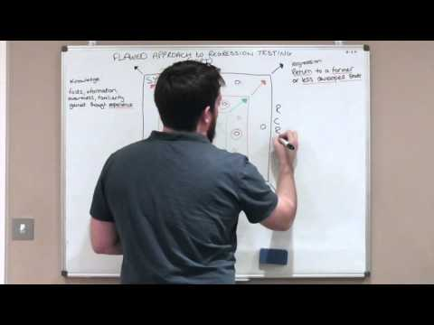

# [Huib Schoots](https://twitter.com/huibschoots). A road to awesomeness

- Be curious. Continuous learning. Testing is about learning
- Deliberate practice. Excellent testing is difficult
- Formal education. Diversify your approach
- Self Education. Read the books
- Training should be challenging and in a safe environment
- Be a mentor
- Practice again and again
- Discuss and debate
- Focus/defocus. Allow time for proceessing thoughts and ideas
- Making mistakes allows you to learn from experience

# [Gwen Diagram](https://twitter.com/gwendiagram). Is test causing your live problems?

- Mantain your test environments as close as possible to live
- Can yo load and performance test TEST?
- Monitoring is a form of testing
- Manual deployments imply human error
- Good monitoring and logging does not imply a good selling product

# [Beren van Daele](https://twitter.com/EnquireTST).Getting the message across

- Bug wall. How to make management understand a problem
- Exploratory testing not accepted as a valueble practice. Need to do thegood testing under the hood
- Inflexible processes and ways of working

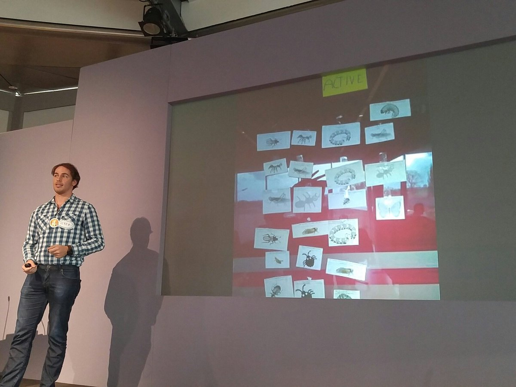

Wall

# 99 Second talks

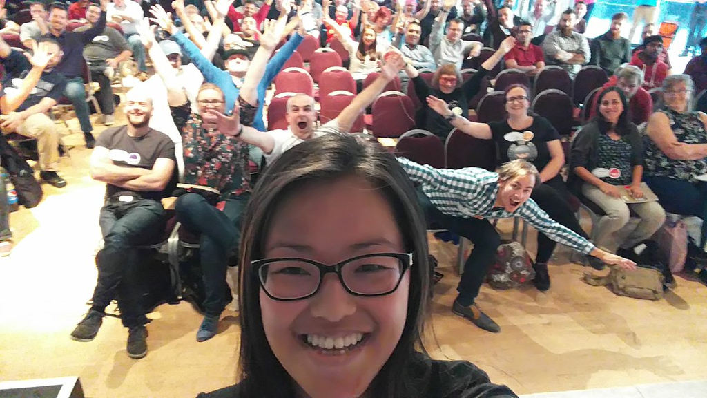

99 Seconds

# Open Conference

- TestSphere. Beren Van Daele
1. Break the ice for new team members
2. Recruitment processes
3. Knowledge sharing

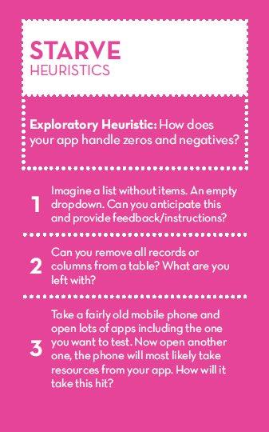

Heuristics

# Open Conference

- Rolegrams. James Bach
1. Rolegrams drive conversations around roles making them visual
2. Tasks, contracts, persons and boundary objects are the key elements
3. Fuzzy lines for undefined. Open lines for inconsistency

# Open Conference

- Importance of developer handovers and dealing without them
- Office Politics: Coping with things that you can’t change